# Data Dive Intro Slides

23. Oktober 2015

## The DataAnimals

**Welcome to the Berlin Data Dive**

In the next slides you will get to know us and learn something about the dataset we have compiled for you. For further questions, feel free to approach one of the present animals at any time during the event.

## Who are we?

We are a group of Berlin-based Master's students with a strong background in data analysis and statistics.

We are a nonprofit with no business interests. Our motivation is to further develop ourselves and our skills beyond textbooks and theories.

## What do we do after the dive?

- Workshops for R, Stata, and Excel
- Data Analysis
- Data Visualisation

Want to know more? Browse http://data-animals.eu, or find http://facebook.com/dataanimals.

## Data Dive

The dataset we compiled contains **98** variables and **141369** observation in total.

Depending on your desired level of analysis, we provide 3 datasets:

1. Student Level
2. School Level (transformed from Student Level)
3. Time Series (transformed from Student Level)

It is cross-sectional time-series data. The intended unit of analysis is the student, although you may want to adapt the level of analysis from student, to school, to district, or region.

## Look at the data

You will find either numeric, string or binary variables.

```
##   student_number student_sex               student_name
## 1  PS0501001-001           M        ALFRED JOSEPH MWITA
## 2  PS0501001-002           M     ATRANUS ALOYS MUTABUZI
## 3  PS0501001-003           M BARTHAZAR DENICE ISHENGELO
## 4  PS0501001-004           M        DANIEL HOSEA SENTOZ
## 5  PS0501001-005           M      DIONIS ROMADIUS KAUTA
## 6  PS0501001-006           M    DONAT DOMINICK MASIKINI
```

## Descriptive Statistics 1 sex ratio

How many female and male students the data consists of?

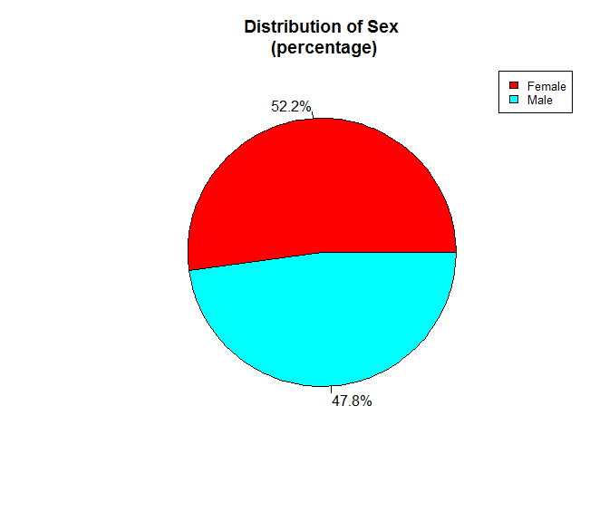

Here we see the total frequency of female and male students.

## Descriptive Statistics 1 sex ratio

How is the sex distribution in class?

```
##    Min. 1st Qu.  Median    Mean 3rd Qu.    Max.
##  0.2400  0.4345  0.4804  0.4798  0.5231  1.0000
```

There are classes with up to 76 % females and classes with 0 % females.

## Descriptive Statistics 2 workshops

How many students are affected by the workshops?

```
## SUM.WORKSHOPS
##          0          1          2          3
## 0.64893006 0.29066246 0.04983229 0.01057519
```

```
## SUM.WORKSHOPS
##     0     1     2     3
## 83577 37435  6418  1362
```

Circa 35% of the students are affected by workshops.

## Descriptive Statistics 2 workshops

How many students are affected by more than one workshop?

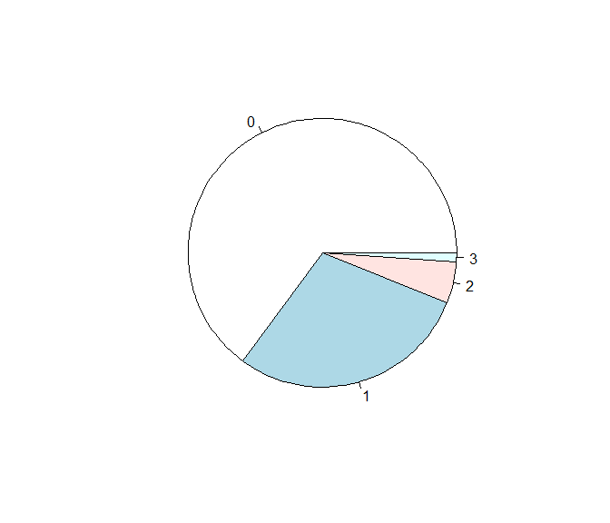

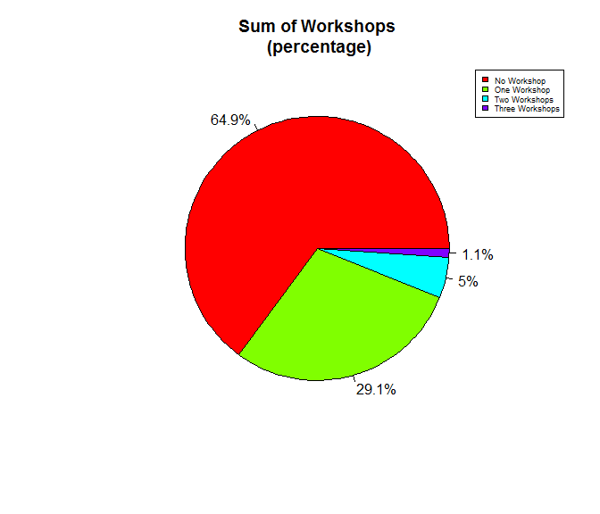

Circa 6% of the students are affected by more than one workshop.

## Descriptive Statistics 2 workshops

How many schools are affected by workshops?

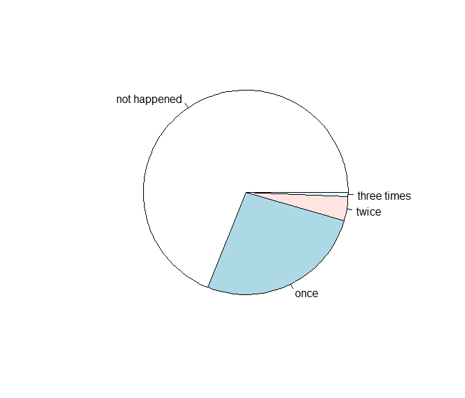

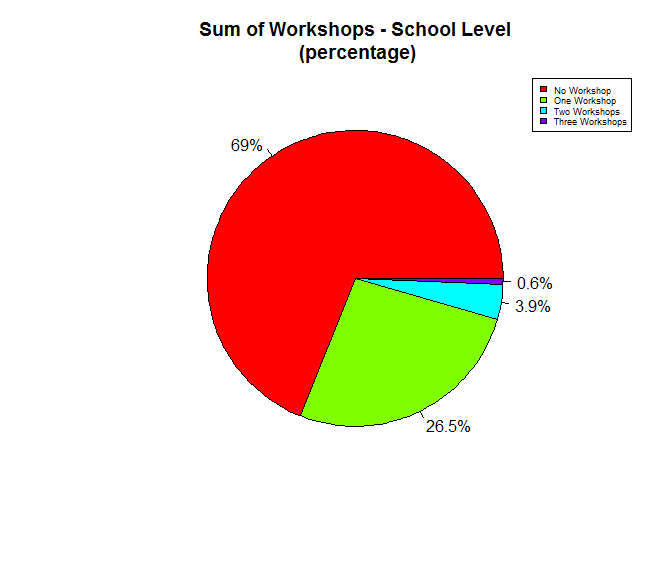

In total 31% of the school had at least one workshop.

## Bar plots

```
##   2013 2014
## 1   15    1
## 2   58    2
```

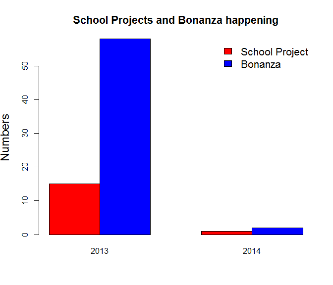

## Bar plots 2

```
##   2013 2014
## 1  410    6
## 2   60    1
## 3   10    0
```

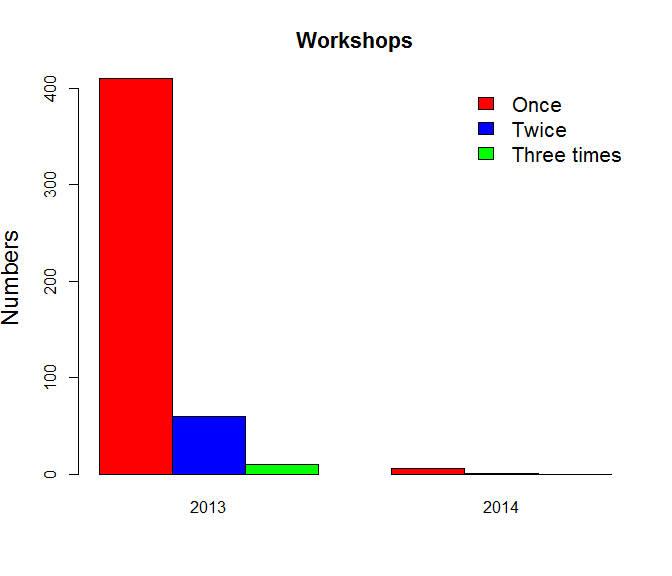

## Warm-up questions

Do you want to familiarize yourself with datasets? Here are simple warm up tasks for you. What is the unique identifier? 1. How many schools have more female than male students? 2. How many students did participate in workshops in 2014? 3. Are grades normally distributed? 4. Are boys better in math and girls better in languages?